# Distribución Normal

Javier Cara

Noviembre-Diciembre 2018

# 1 El histograma

## 1.1 Datos

Datos procedentes de http://jse.amstat.org/v11n2/datasets.heinz.html

```r
d <- read.table("body.dat.txt")
```

Las últimas columnas son:

- Columna 22: Age (years)
- Columna 23: Weight (kg)
- Columna 24: Height (cm)
- Columna 25: Gender (1 - male, 0 - female)

```r
# peso
altura = d[,24]
# peso de los hombres
alturaH = altura[d[,25] == 1]
```

## 1.2 Histograma en frecuencias absolutas

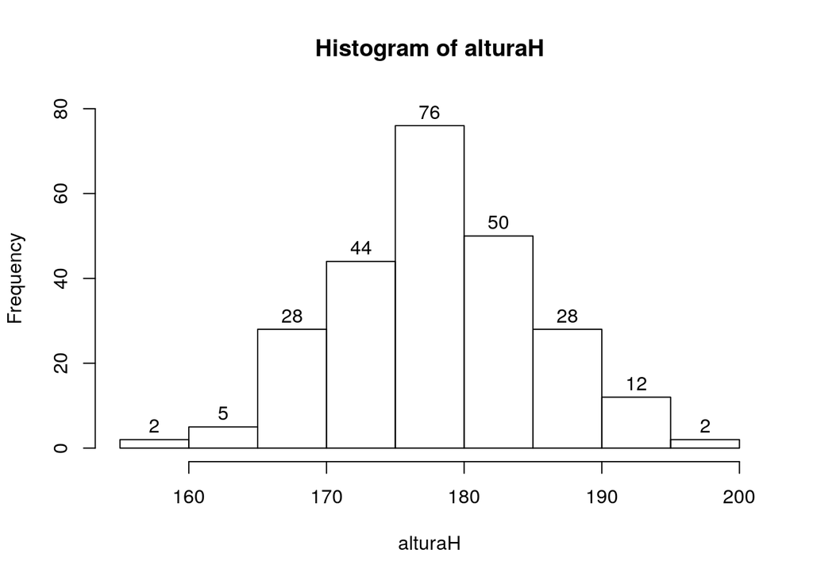

```r
h = hist(alturaH, freq = T, labels = T, ylim = c(0,80))
```

```r
str(h)
```

```
## List of 6
##  $ breaks  : int [1:10] 155 160 165 170 175 180 185 190 195 200
##  $ counts  : int [1:9] 2 5 28 44 76 50 28 12 2
##  $ density : num [1:9] 0.00162 0.00405 0.02267 0.03563 0.06154 ...
##  $ mids    : num [1:9] 158 162 168 172 178 ...
##  $ xname   : chr "alturaH"
##  $ equidist: logi TRUE
##  - attr(*, "class")= chr "histogram"
```

- Número de hombres con una altura entre 170 y 175 cm:

```r
h$counts[4]
```

```
## [1] 44
```

- Número de hombres con una altura menor de 180 cm:

```r
sum(h$counts[1:5])
```

```
## [1] 155
```

## 1.3 Histograma en frecuencias relativas

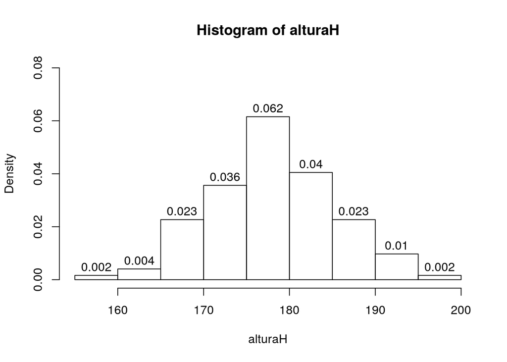

```r
hist(alturaH, freq = F, labels = T, ylim = c(0,0.08))
```

- Las frecuencias relativas son las frecuencias absolutas entre el numero total de datos:

```r
( fr = h$counts / sum(h$counts) )
```

```
## [1] 0.008097166 0.020242915 0.113360324 0.178137652 0.307692308 0.202429150
## [7] 0.113360324 0.048582996 0.008097166
```

- La altura del intervalo *i* (clase) es:

```r
round( fr/5, 3) # dividimos por la longitud del intervalo, porque el area del histograma es 1
```

```
## [1] 0.002 0.004 0.023 0.036 0.062 0.040 0.023 0.010 0.002
```

- Proporción de hombres con una altura entre 170 y 175 cm:

```r
h$counts[4] / sum(h$counts)
```

```
## [1] 0.1781377
```

- Proporción de hombres con una altura menor de 180 cm:

```r
sum(h$counts[1:5]) / sum(h$counts)
```

```
## [1] 0.6275304
```

- El area de todo es histograma es 1:

```r
sum(h$counts[1:9]) / sum(h$counts)
```

```
## [1] 1
```

## 1.4 Aproximación del histograma con una curva continua

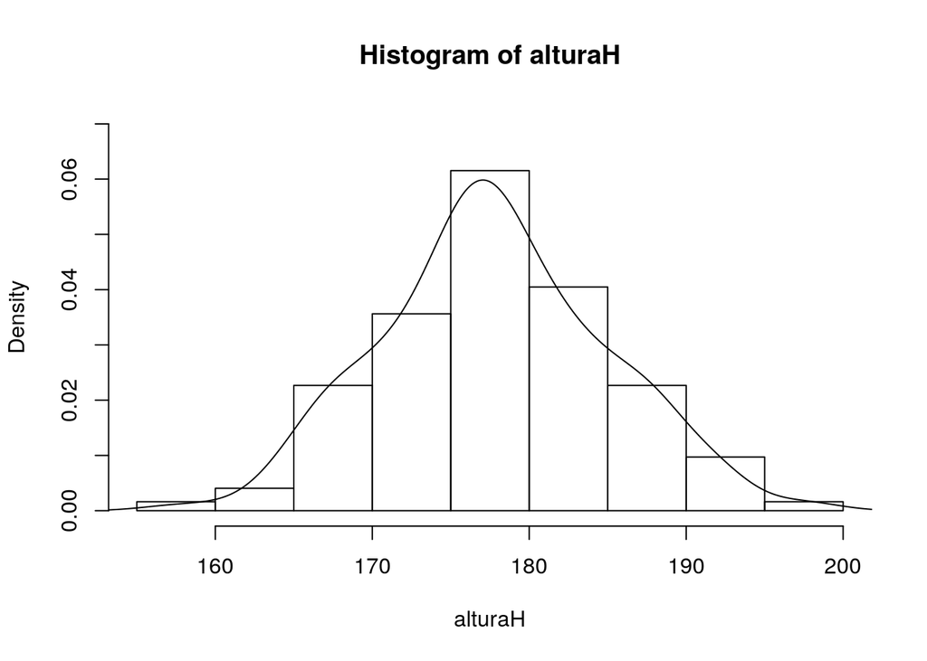

```r
hist(alturaH, freq = F, ylim = c(0,0.07))
lines(density(alturaH))
```

## 1.5 Aproximación del histograma con la distribución normal

Vamos a utilizar una curva continua con ecuación conocida:

$$f(x) = \frac{1}{\sigma \sqrt{2\pi}}e^{-\frac{1}{2\sigma^2}(x-\mu)^2}$$

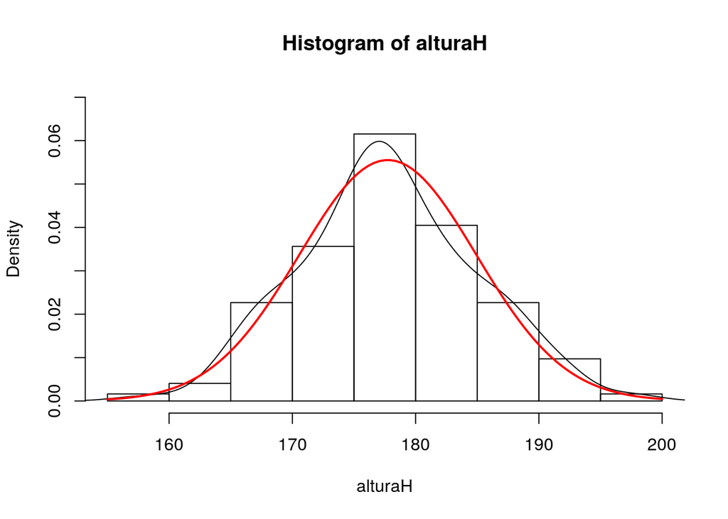

```r
hist(alturaH, freq = F, ylim = c(0,0.07))
lines(density(alturaH))
mu = mean(alturaH)
sigma = sd(alturaH)
curve(dnorm(x, mu, sigma), add = T, col = "red", lwd=2)
```

```r
# proporción de hombres con una altura menor de 180
pnorm(180, mean = mu, sd = sigma)
```

```
## [1] 0.6231864
```

La aproximación es buena.

```r
# proporción de hombres con una altura entre 170 y 175
(p = pnorm(c(175,170), mean = mu, sd = sigma))
```

```
## [1] 0.3511688 0.1404736
```

```r
p[1] - p[2]
```

```
## [1] 0.2106952
```

- El área bajo la curva de la distribución normal es 1:

```r
pnorm(200, mu, sigma)
```

```
## [1] 0.9990257
```

# 2 La distribución normal

## 2.1 Definición

La función de densidad de la distribución normal se define como:

$$f(x) = \frac{1}{\sigma \sqrt{2\pi}}e^{-\frac{1}{2\sigma^2}(x-\mu)^2}$$

$$P(X < a) = \int_{-\infty}^a f(x) dx$$

$$P(a < X < b) = \int_{a}^b f(x) dx = \int_{-\infty}^b f(x) dx - \int_{-\infty}^a f(x) dx = P(X < b) - P(X < a)$$

## 2.2 Parámetros de la distribución normal

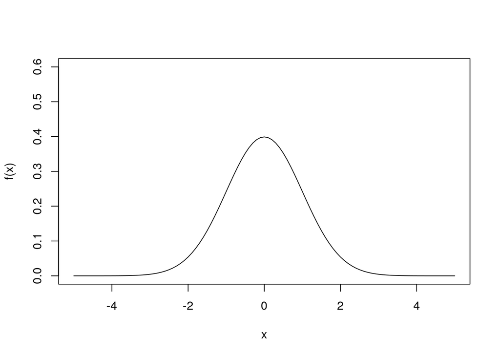

```r
curve(dnorm(x, 0, 1), from = -5, to = 5, ylab = "f(x)", ylim = c(0,0.6))
```

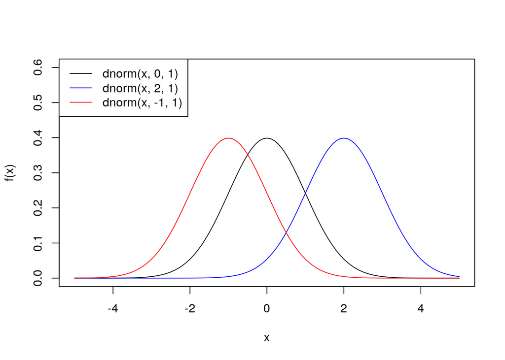

```r
curve(dnorm(x, 0, 1), from = -5, to = 5, ylab = "f(x)", ylim = c(0,0.6))
curve(dnorm(x, 2, 1), from = -5, to = 5, add = T, col = "blue")
curve(dnorm(x, -1, 1), from = -5, to = 5, add = T, col = "red")
legend("topleft", legend = c("dnorm(x, 0, 1)","dnorm(x, 2, 1)","dnorm(x, -1, 1)"), col = c("black","blue","red"), lty = 1, lwd = 1)
```

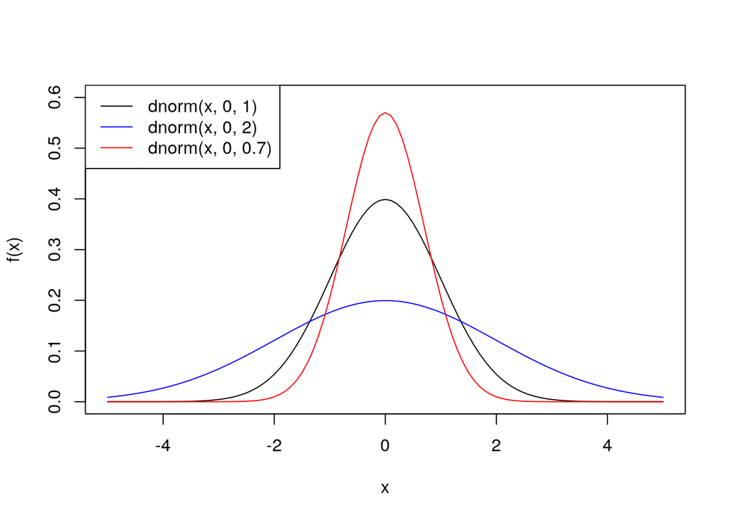

```r
curve(dnorm(x, 0, 1), from = -5, to = 5, ylab = "f(x)", ylim = c(0,0.6))
curve(dnorm(x, 0, 2), from = -5, to = 5, add = T, col = "blue")
curve(dnorm(x, 0, 0.7), from = -5, to = 5, add = T, col = "red")
legend("topleft", legend = c("dnorm(x, 0, 1)","dnorm(x, 0, 2)","dnorm(x, 0, 0.7)"), col = c("black","blue","red"), lty = 1, lwd = 1)
```

## 2.3 Cálculo de probabilidades

1. Proporción de tornillos no aceptables por cortos.
2. Proporción de tornillos no aceptables por largos.
3. Proporción de tornillos válidos.

*SOLUCIÓN*

```r
# Apartado 1
pnorm(29.5, mean = 30, sd = 0.2)
```

```
## [1] 0.006209665
```

```r
# Apartado 2
pnorm(30.4, mean = 30, sd = 0.2, lower.tail = F)
```

```
## [1] 0.02275013
```

```r
# también
1 - pnorm(30.4, mean = 30, sd = 0.2)
```

```
## [1] 0.02275013
```

```r
# Apartado 3
(p = pnorm(c(29.5,30.4), mean = 30, sd = 0.2))
```

```
## [1] 0.006209665 0.977249868
```

```r
p[2] - p[1]
```

```
## [1] 0.9710402
```

## 2.4 La distribución N(0,1)

**Teorema**

Si $X \sim N(\mu,\sigma)$ entonces $Z = \frac{X-\mu}{\sigma} \sim N(0,1)$

**Consecuencia**

$$P \left( X < a \right) = P \left( \frac{X-\mu}{\sigma} \leq \frac{a-\mu}{\sigma} \right) = P \left( Z \leq \frac{a-\mu}{\sigma} \right)$$

```r
# X ~ N(5,3)
pnorm(7.5, mean = 5, sd = 3)
```

```
## [1] 0.7976716
```

```r
# Z = (X-5)/3 ~ N(0,1)
pnorm((7.5-5)/3, mean = 0, sd = 1)
```

```
## [1] 0.7976716
```

## 2.5 Generacion numeros aleatorios en la N(0,1)

- El número de datos que se generan (aleatoriamente) en el intervalo [a,b] es proporcional al área de la N(0,1) en el intervalo [a,b]:

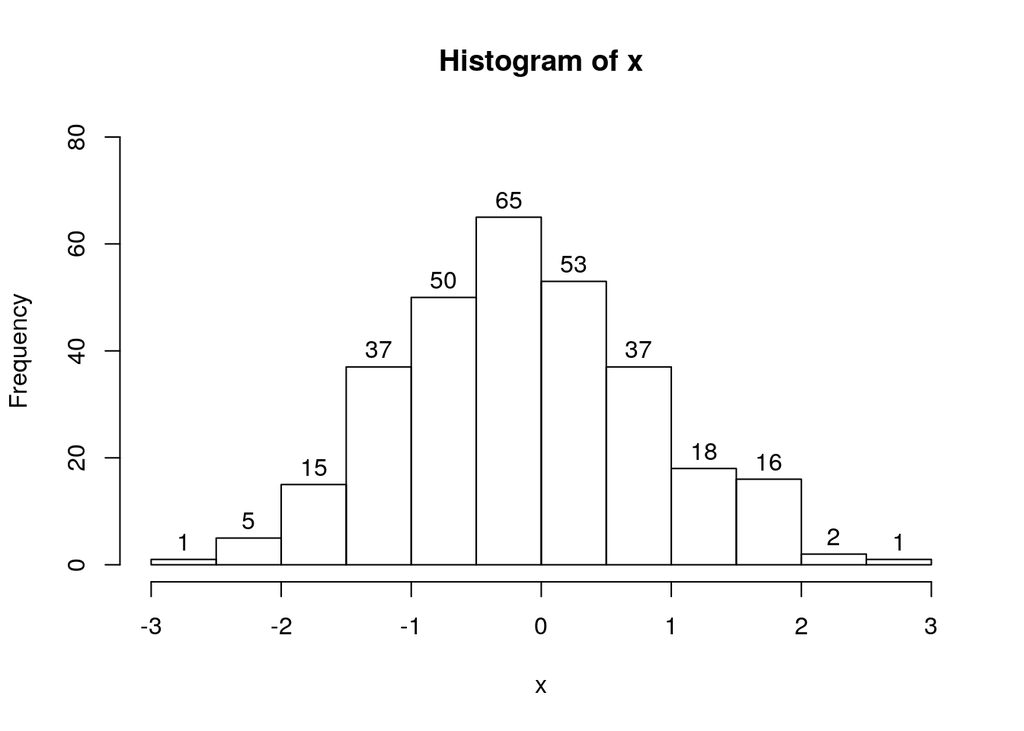

```r
set.seed(543)
x = rnorm(300,0,1)
hist(x, labels = T, ylim = c(0,80))
```

- Podemos comprobarlo superponiendo la N(0,1) al histograma:

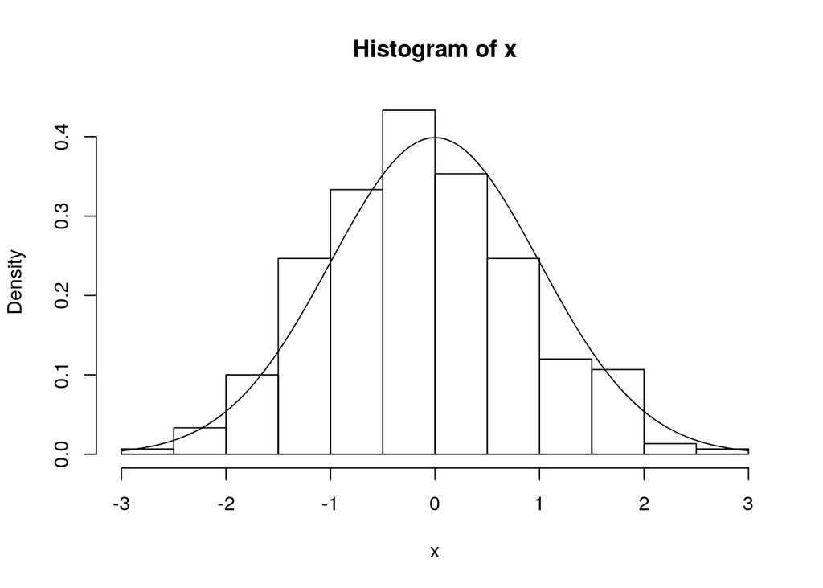

```r
hist(x, freq = F)
curve(dnorm(x,0,1), add = T)
```

## 2.6 Suma de variables normales

TEOREMA

Sean $X_1 \sim N(\mu_1, \sigma_1)$ y $X_2 \sim N(\mu_2, \sigma_2)$. Se tiene que:

$$X_1 + X_2 \sim N(\mu_1 + \mu_2, \sqrt{\sigma_1^2 + \sigma_2^2})$$

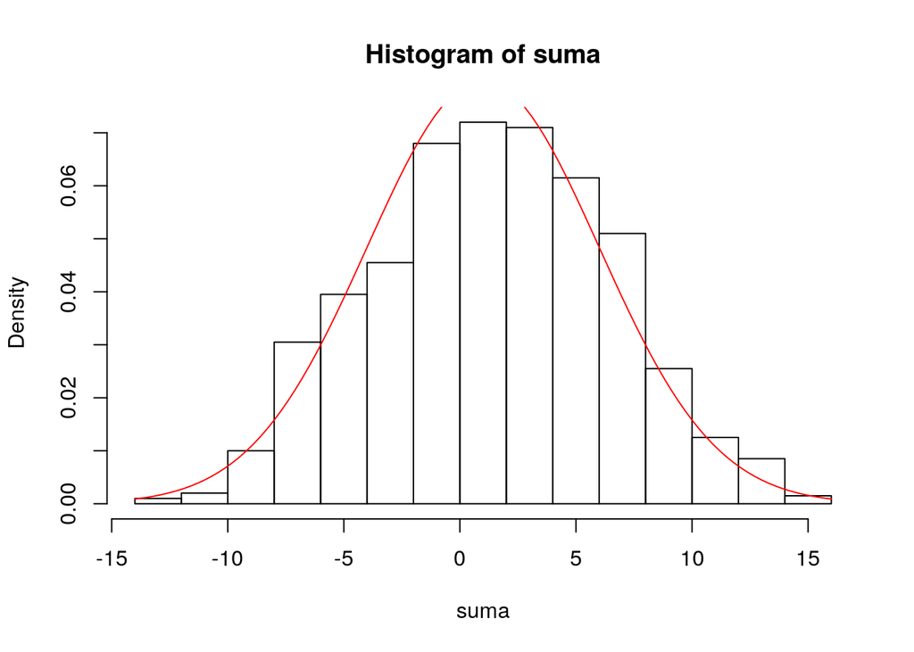

```r
mu1 = -1
sigma1 = 3
mu2 = 2
sigma2 = 4
# simulamos
set.seed(553)
n = 1000
X1 = rnorm(n,mu1,sigma1)
X2 = rnorm(n,mu2,sigma2)
suma = X1 + X2
hist(suma, freq = F)
curve( dnorm(x, mean = mu1+mu2, sd = sqrt(sigma1^2 + sigma2^2)), add = T, col = "red")
```

## 2.7 El Teorema Central del Límite

**Teorema 1**

Si tenemos *n* variables aleatorias que tienen la misma función de densidad, entonces la suma de esas variables tiene distribución normal (conforme $n \rightarrow \infty$).

EJEMPLO

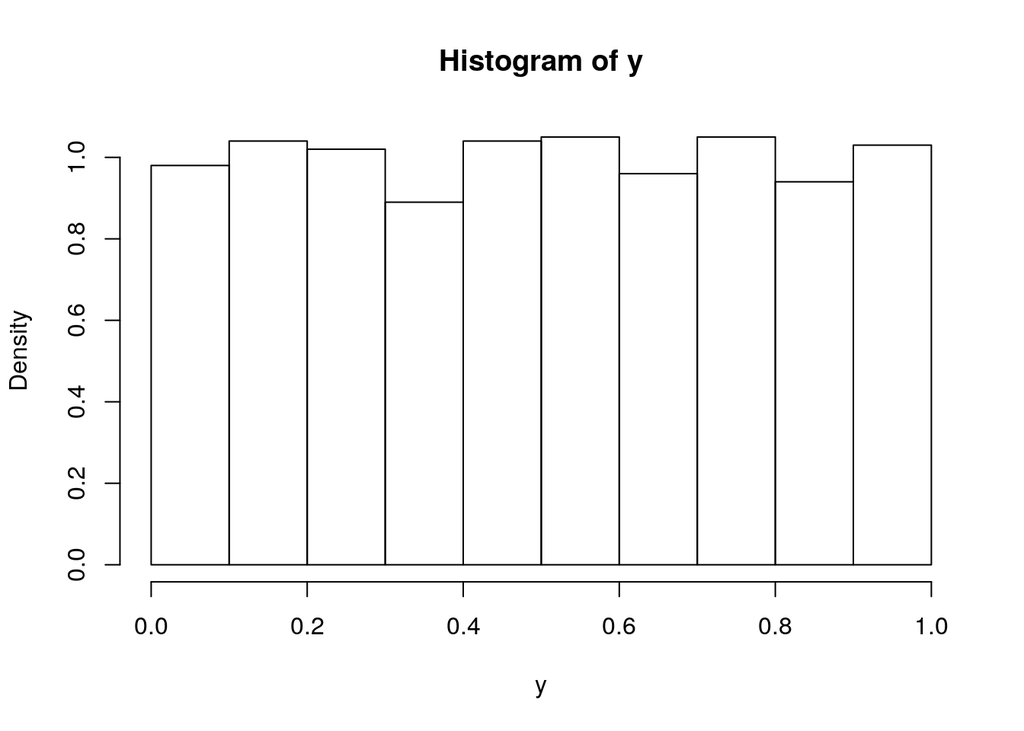

```r
# n variables con distribución uniforme
y = runif(1000)
hist(y, freq = F)
```

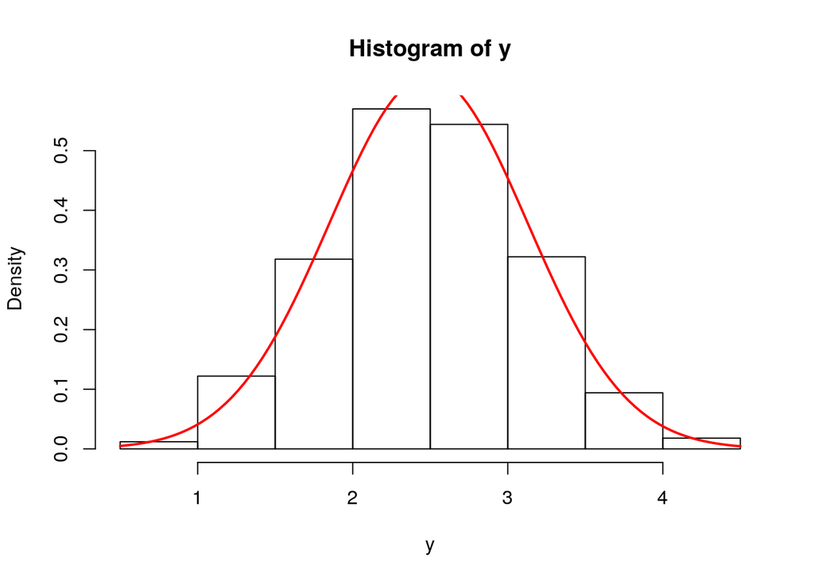

```r
n = 5
y = rep(0,1000)
for (i in 1:n){
  y = y + runif(1000)
}
hist(y, freq = F)
curve(dnorm(x, mean = mean(y), sd = sd(y)), add = T, col = "red", lwd = 2)
```

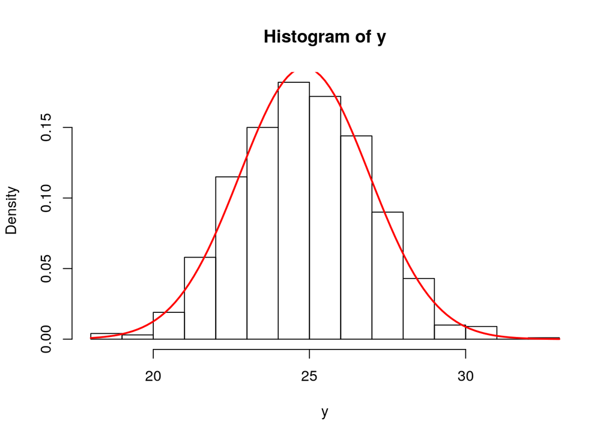

```r
n = 50
y = rep(0,1000)
for (i in 1:n){
  y = y + runif(1000)
}
hist(y, freq = F)
curve(dnorm(x, mean = mean(y), sd = sd(y)), add = T, col = "red", lwd = 2)
```

**Teorema 2**

EJEMPLO

```r
# media y desviacion tipica de la distribucion uniforme (teoria)
mu = 1/2
sigma = sqrt(1/12)
# por ejemplo, en una simulacion
xi = runif(1000)
data.frame(teoria = c(mu, sigma), simulacion = c(mean(xi), sd(xi)), row.names = c("mu", "sigma"))
```

```
##          teoria simulacion
## mu    0.5000000  0.5229979
## sigma 0.2886751  0.2934835
```

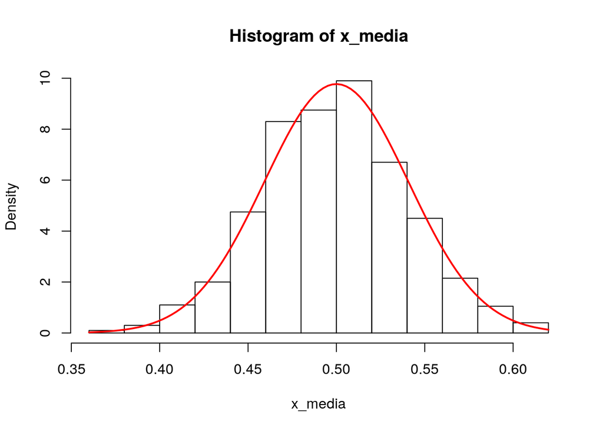

```r
n = 50
x = rep(0,1000)
for (i in 1:n){
  x = x + runif(1000)
}
x_media = x / n
hist(x_media, freq = F)
curve(dnorm(x, mean = mu, sd = sigma/sqrt(n)), add = T, col = "red", lwd = 2)
```

# 3 Comprobación gráfica de la normalidad

## 3.1 Histograma

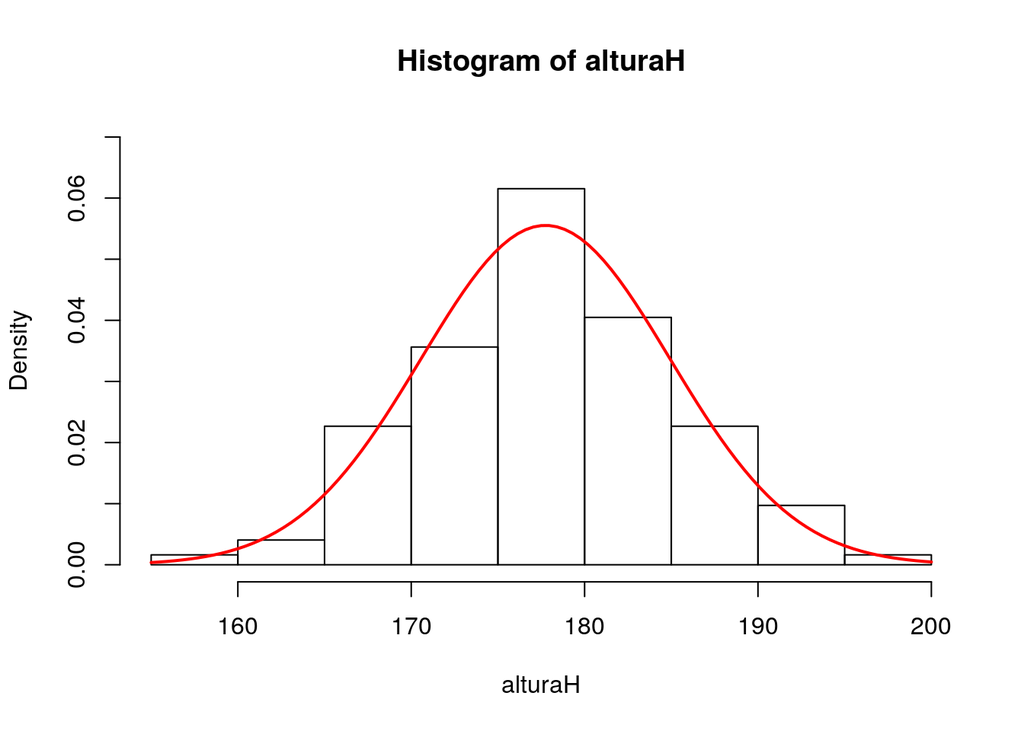

```r
hist(alturaH, freq = F, ylim = c(0,0.07))
curve(dnorm(x, mean = mean(alturaH), sd = sd(alturaH)), add = T, col = "red", lwd=2)
```

## 3.2 Gráfico probabilista normal (Q-Q plot)

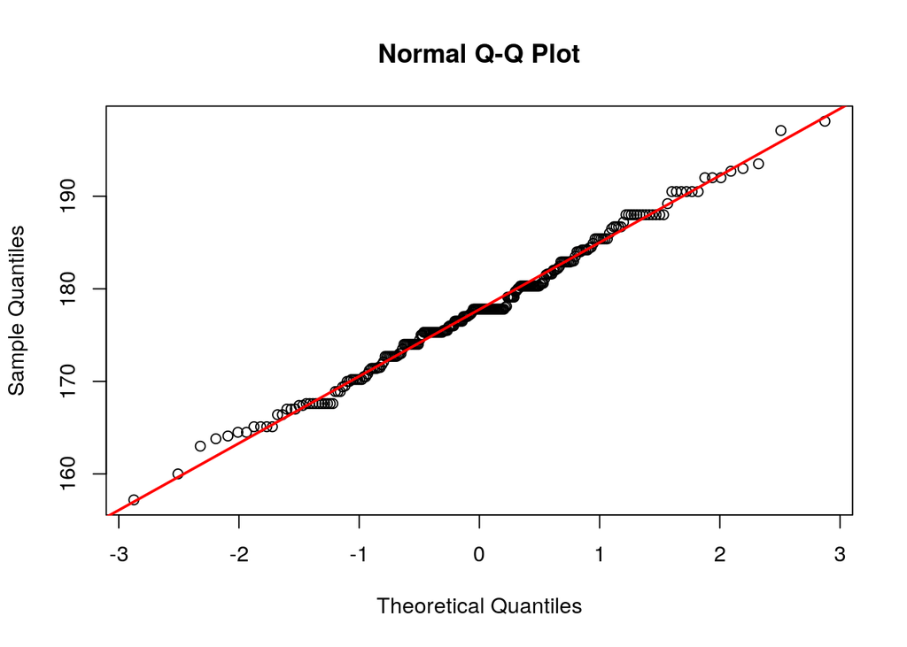

```r
qqnorm(alturaH)
qqline(alturaH, col = "red", lwd = 2)
```

- Sample Quantiles: son los datos ordenados, de menor a mayor.

```r
SampleQ = sort(alturaH)
```

- Theoretical Quantiles: son los cuantiles de la N(0,1) correspondientes a $(i-0.5)/n$, donde *n* es el número de datos, $i=1,2,\cdots,n$.

```r
n = length(alturaH)
i = 1:n
q = (i-0.5)/n
TheoreticalQ = qnorm(q)
```

- Se representa TheoreticalQ *vs* sampleQ.

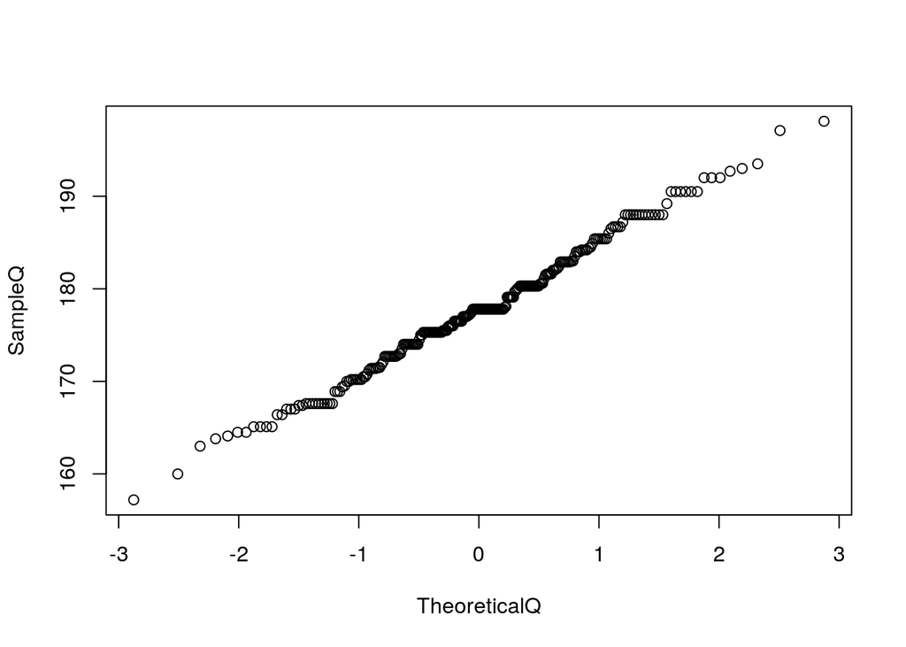

```r
plot(TheoreticalQ,SampleQ)
```

- Según la ayuda de R, *qqline()* pasa por el primer y tercer cuartil.

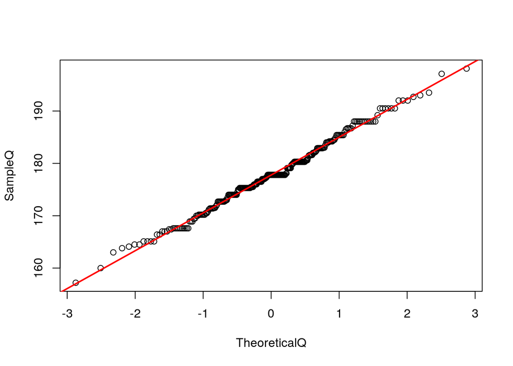

```r
plot(TheoreticalQ,SampleQ)

# qqline
x1 <- qnorm(0.25)
x2 <- qnorm(0.75)
y1 <- quantile(alturaH, 0.25)
y2 <- quantile(alturaH, 0.75)
b = (y2-y1)/(x2-x1) # pendiente
a = y1 - b*x1 # y1 = a + b*x1
abline(a,b, col = "red", lwd = 2) # y = a + b*x
```